# Lab sessions 4 - Bayesian Statistics

May, 9 2019

## Cockroaches

**1** Load and explore the dataset in the file `pest_data.RDS`. The dataset includes 14 variables, that are:

- `complaints`: Number of complaints per building per month
- `building_id`: The unique building identifier
- `traps`: The number of traps used per month per building
- `date`: The date at which the number of complaints are recorded
- `live_in_super`: An indicator for whether the building has a live-in super
- `age_of_building`: The age of the building
- `total_sq_foot`: The total square footage of the building
- `average_tenant_age`: The average age of the tenants per building
- `monthly_average_rent`: The average monthly rent per building
- `floors`: The number of floors per building

```r
library(rstan)
library(dplyr)
library(lubridate)
library(ggplot2)
library(bayesplot)

theme_set(bayesplot::theme_default())

# seed for R's pseudo-RNGs, not Stan's
set.seed(1123)
```

```r
pest_data <- readRDS('pest_data.RDS')
str(pest_data)
```

```
## 'data.frame':    120 obs. of  14 variables:
##  $ mus                 : num  0.369 0.359 0.282 0.129 0.452 ...
##  $ building_id         : int  37 37 37 37 37 37 37 37 37 37 ...
##  $ wk_ind              : int  1 2 3 4 5 6 7 8 9 10 ...
##  $ date                : Date, format: "2017-01-15" "2017-02-14" ...
##  $ traps               : num  8 8 9 10 11 11 10 10 9 9 ...
##  $ floors              : num  8 8 8 8 8 8 8 8 8 8 ...
##  $ sq_footage_p_floor  : num  5149 5149 5149 5149 5149 ...
##  $ live_in_super       : num  0 0 0 0 0 0 0 0 0 0 ...
##  $ monthly_average_rent: num  3847 3847 3847 3847 3847 ...
##  $ average_tenant_age  : num  53.9 53.9 53.9 53.9 53.9 ...
##  $ age_of_building     : num  47 47 47 47 47 47 47 47 47 47 ...
##  $ total_sq_foot       : num  41192 41192 41192 41192 41192 ...
##  $ month               : num  1 2 3 4 5 6 7 8 9 10 ...
##  $ complaints          : num  1 3 0 1 0 0 4 3 2 2 ...
```

```r
summary(pest_data)
```

```
##       mus           building_id       wk_ind           date
##  Min.   :-0.1008   Min.   : 5.0   Min.   : 1.00   Min.   :2017-01-15
##  1st Qu.: 0.5279   1st Qu.:26.0   1st Qu.: 3.75   1st Qu.:2017-04-07
##  Median : 1.0422   Median :46.0   Median : 6.50   Median :2017-06-29
##  Mean   : 1.1116   Mean   :49.6   Mean   : 6.50   Mean   :2017-06-29
##  3rd Qu.: 1.6837   3rd Qu.:70.0   3rd Qu.: 9.25   3rd Qu.:2017-09-19
##  Max.   : 2.8030   Max.   :98.0   Max.   :12.00   Max.   :2017-12-11
##      traps            floors     sq_footage_p_floor live_in_super
##  Min.   : 1.000   Min.   : 4.0   Min.   :4186       Min.   :0.0
##  1st Qu.: 6.000   1st Qu.: 8.0   1st Qu.:4770       1st Qu.:0.0
##  Median : 7.000   Median :10.0   Median :5097       Median :0.0
##  Mean   : 7.033   Mean   : 9.9   Mean   :4991       Mean   :0.3
##  3rd Qu.: 8.000   3rd Qu.:13.0   3rd Qu.:5206       3rd Qu.:1.0
##  Max.   :11.000   Max.   :15.0   Max.   :5740       Max.   :1.0
##  monthly_average_rent average_tenant_age age_of_building total_sq_foot
##  Min.   :3029         Min.   :41.14      Min.   :39.0    Min.   :19217
##  1st Qu.:3564         1st Qu.:45.14      1st Qu.:47.0    1st Qu.:41192
##  Median :3813         Median :48.20      Median :49.0    Median :47096
##  Mean   :3687         Mean   :49.92      Mean   :49.4    Mean   :49248
##  3rd Qu.:3864         3rd Qu.:53.88      3rd Qu.:51.0    3rd Qu.:59251
##  Max.   :4019         Max.   :65.18      Max.   :60.0    Max.   :78093
##      month         complaints
##  Min.   : 1.00   Min.   : 0.000
##  1st Qu.: 3.75   1st Qu.: 1.000
##  Median : 6.50   Median : 2.000
##  Mean   : 6.50   Mean   : 3.658
##  3rd Qu.: 9.25   3rd Qu.: 5.250
##  Max.   :12.00   Max.   :18.000
```

```r
##number of buildings
N_buildings <- length(unique(pest_data$building_id))
N_buildings
```

```
## [1] 10
```

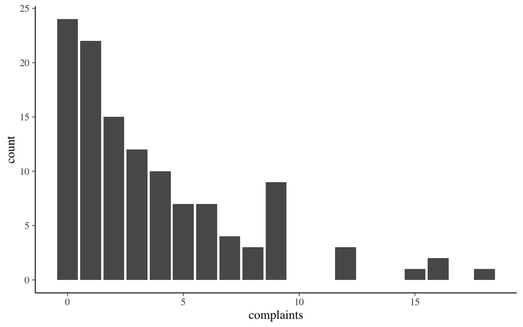

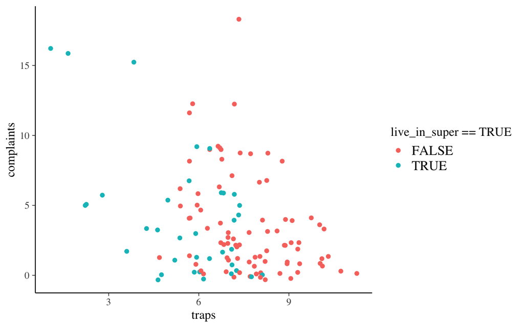

[figure not shown]

```r
ggplot(pest_data, aes(x = date, y = complaints, color = live_in_super == TRUE)) +
  geom_line(aes(linetype = "Number of complaints")) +
  geom_point(color = "black") +
  geom_line(aes(y = traps, linetype = "Number of traps"), color = "black", size = 0.25) +
  facet_wrap(~building_id, scales = "free", ncol = 2, labeller = label_both) +
  scale_x_date(name = "Month", date_labels = "%b") +
  scale_y_continuous(name = "", limits = range(pest_data$complaints)) +
  scale_linetype_discrete(name = "") +
  scale_color_discrete(name = "Live-in super")
```

**2** Write the following Poisson model in stan. Is the number of complaints associated with the number of traps?

$$\begin{align*}
\textrm{complaints}_i & \sim \textrm{Poisson}(\lambda_i) \\
\lambda_i & = \exp{(\eta_i)} \\
\eta_i &= \alpha + \beta \, \textrm{traps}_i
\end{align*}$$

```r
## compile the model
comp_model_P <- stan_model('simple_poisson_regression2.stan')
```

```r
## arrange data into a list
stan_dat_simple <- list(
  N = nrow(pest_data),
  complaints = pest_data$complaints,
  traps = pest_data$traps
)
str(stan_dat_simple)
```

```
## List of 3
##  $ N         : int 120
##  $ complaints: num [1:120] 1 3 0 1 0 0 4 3 2 2 ...
##  $ traps     : num [1:120] 8 8 9 10 11 11 10 10 9 9 ...
```

```r
## fit the model
fit_P_real_data <- sampling(comp_model_P, data = stan_dat_simple)
## print the parameters
print(fit_P_real_data, pars = c('alpha','beta'))
```

```
## Inference for Stan model: simple_poisson_regression2.
## 4 chains, each with iter=2000; warmup=1000; thin=1;
## post-warmup draws per chain=1000, total post-warmup draws=4000.
##
##        mean se_mean   sd  2.5%   25%   50%   75% 97.5% n_eff Rhat
## alpha  2.57    0.01 0.15  2.28  2.46  2.57  2.68  2.87   909    1
## beta  -0.19    0.00 0.02 -0.24 -0.21 -0.19 -0.17 -0.15   894    1
##
## Samples were drawn using NUTS(diag_e) at Thu May  9 01:00:37 2019.
## For each parameter, n_eff is a crude measure of effective sample size,
## and Rhat is the potential scale reduction factor on split chains (at
## convergence, Rhat=1).
```

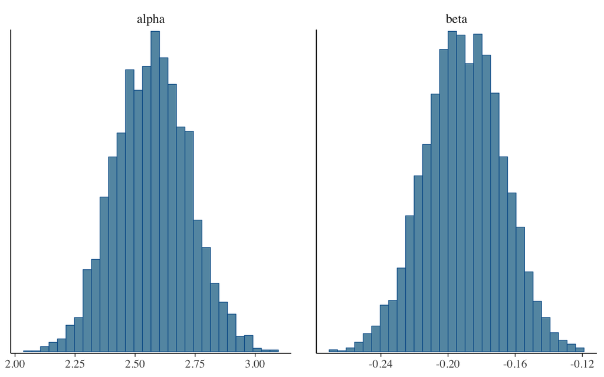

```r
mcmc_hist(as.matrix(fit_P_real_data, pars = c('alpha','beta')))
```

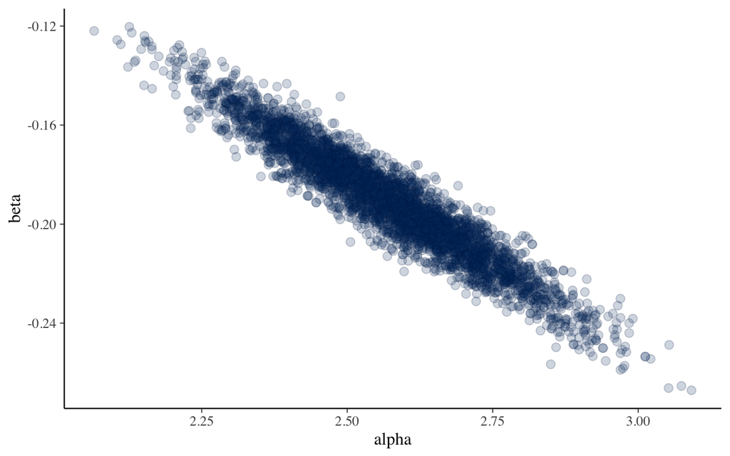

```r
mcmc_scatter(as.matrix(fit_P_real_data, pars = c('alpha','beta')), alpha = 0.2)
```

It appears that there is association between the number of bait stations and the number of complaints.

**3** Verify that the ‘Poisson’ assumption in the Poisson generalised linear model is not satisfied. Improve your model including the indicator variable for whether the building has a live-in super and the total square footage of the building (offset).

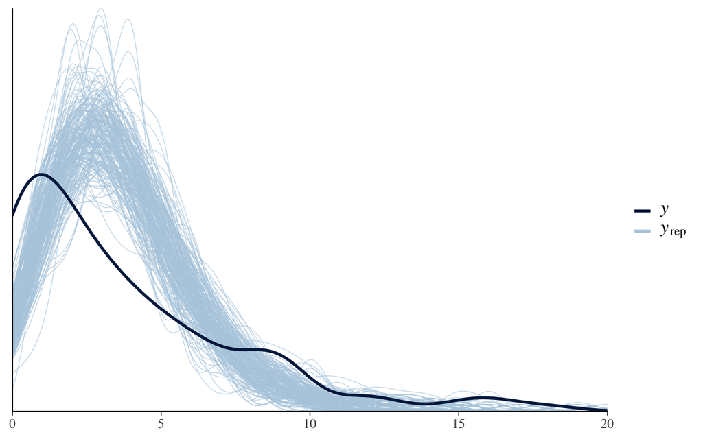

```r
## posterior predictive checking
y_rep <- as.matrix(fit_P_real_data, pars = "y_rep")
ppc_dens_overlay(y = stan_dat_simple$complaints, y_rep[1:200,])
```

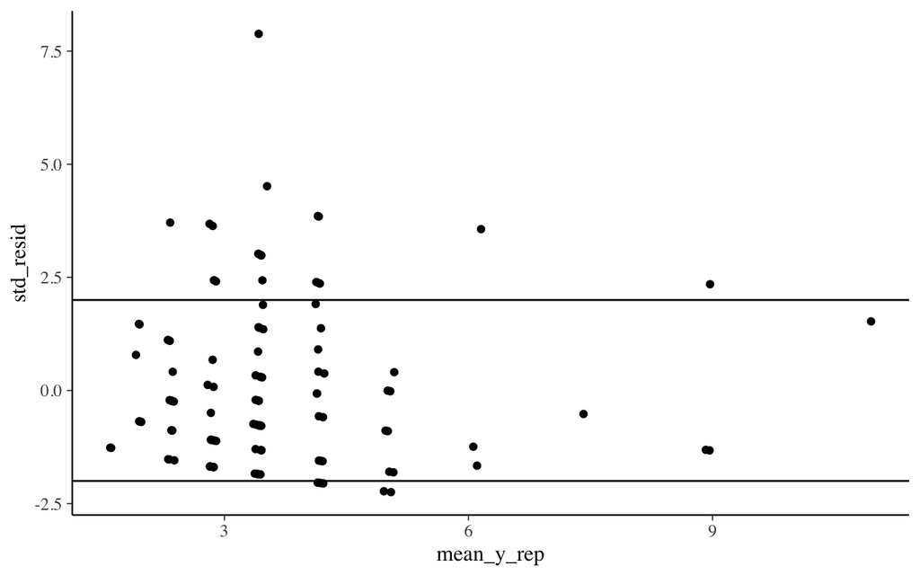

```r
## standardised residuals of the observed vs predicted number of complaints
mean_y_rep <- colMeans(y_rep)
std_resid <- (stan_dat_simple$complaints - mean_y_rep) / sqrt(mean_y_rep)
qplot(mean_y_rep, std_resid) + hline_at(2) + hline_at(-2)
```

Residuals are mostly positive, thus the model tends to underestimate the number of complaints.

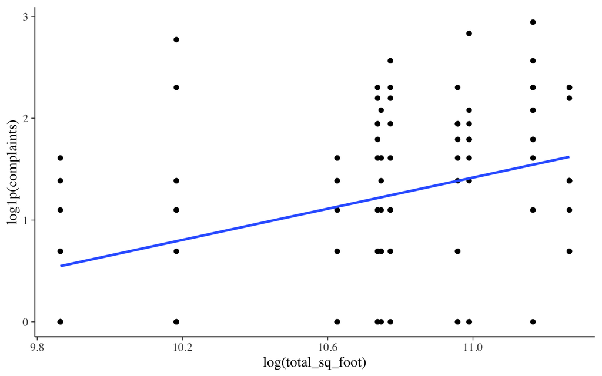

```r
ggplot(pest_data, aes(x = log(total_sq_foot), y = log1p(complaints))) +
  geom_point() +
  geom_smooth(method = "lm", se = FALSE)
```

$$\begin{align*}
\textrm{complaints}_i & \sim \textrm{Poisson}(\lambda_i) \\
\lambda_i & = \exp{(\eta_i)} \\
\eta_i &= \alpha + \beta \, \textrm{traps}_i + \beta_{\rm super} \, {\rm super}_{i} + \text{log_sq_foot}_{i}
\end{align*}$$

```r
## add the two variables to the list of the data
stan_dat_simple$log_sq_foot <- log(pest_data$total_sq_foot/1e4)
stan_dat_simple$live_in_super <- pest_data$live_in_super
str(stan_dat_simple)
```

```
## List of 5
##  $ N            : int 120
##  $ complaints   : num [1:120] 1 3 0 1 0 0 4 3 2 2 ...
##  $ traps        : num [1:120] 8 8 9 10 11 11 10 10 9 9 ...
##  $ log_sq_foot  : num [1:120] 1.42 1.42 1.42 1.42 1.42 ...
##  $ live_in_super: num [1:120] 0 0 0 0 0 0 0 0 0 0 ...
```

```r
## compile the model
comp_model_P_mult <- stan_model('multiple_poisson_regression.stan')
```

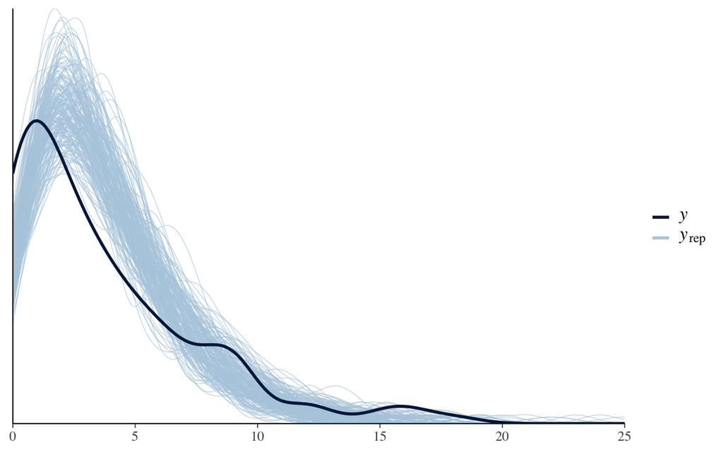

```r
fit_model_P_mult_real <- sampling(comp_model_P_mult, data = stan_dat_simple)
y_rep <- as.matrix(fit_model_P_mult_real, pars = "y_rep")
ppc_dens_overlay(stan_dat_simple$complaints, y_rep[1:200,])
```

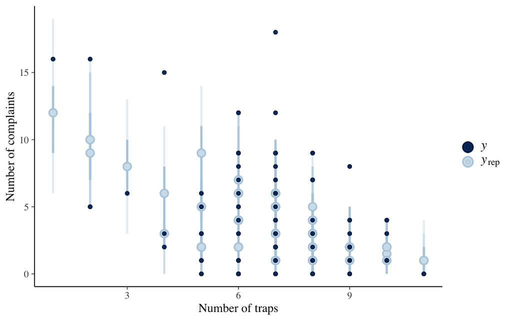

```r
ppc_intervals(
  y = stan_dat_simple$complaints,
  yrep = y_rep,
  x = stan_dat_simple$traps
) +
  labs(x = "Number of traps", y = "Number of complaints")
```

**4** Write the following model in stan and compare results with the previous model.

$$\begin{align*}
\text{complaints}_i & \sim \text{Neg-Binomial}(\lambda_i, \phi) \\
\lambda_i & = \exp{(\eta_i)} \\
\eta_i &= \alpha + \beta \, {\rm traps}_i + \beta_{\rm super} \, {\rm super}_{i} + \text{log_sq_foot}_{i}
\end{align*}$$

In Stan the negative binomial mass function we’ll use is called $\texttt{neg_binomial_2_log}(\text{ints} \, y, \text{reals} \, \eta, \text{reals} \, \phi)$ in Stan. Like the `poisson_log` function, this negative binomial mass function that is parameterized in terms of its log-mean, $\eta$, but it also has a precision $\phi$ such that

$$\mathbb{E}[y] \, = \lambda = \exp(\eta)$$

$$\text{Var}[y] = \lambda + \lambda^2/\phi = \exp(\eta) + \exp(\eta)^2 / \phi.$$

As $\phi$ gets larger the term $\lambda^2 / \phi$ approaches zero and so the variance of the negative-binomial approaches $\lambda$, i.e., the negative-binomial gets closer and closer to the Poisson.

```r
comp_model_NB <- stan_model('multiple_NB_regression.stan')
```

```r
fitted_model_NB <- sampling(comp_model_NB, data = stan_dat_simple)
samps_NB <- rstan::extract(fitted_model_NB)
```

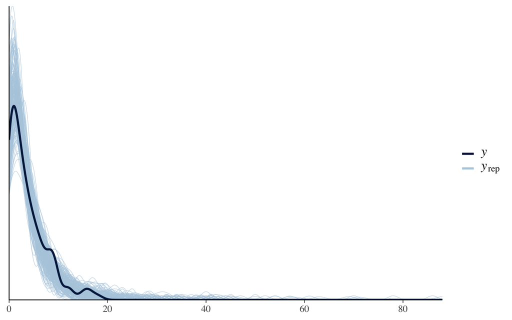

```r
## predictions vs. the data
y_rep <- samps_NB$y_rep
ppc_dens_overlay(stan_dat_simple$complaints, y_rep[1:200,])
```

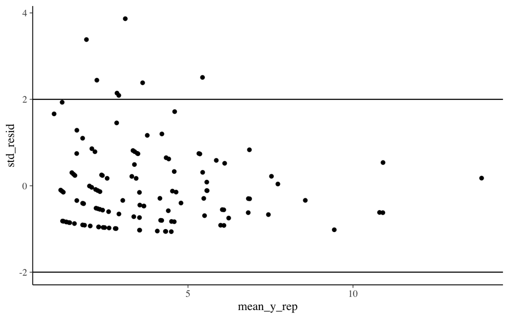

```r
## standardisd residuals
mean_inv_phi <- mean(samps_NB$inv_phi)
mean_y_rep <- colMeans(y_rep)
std_resid <- (stan_dat_simple$complaints - mean_y_rep) / sqrt(mean_y_rep + mean_y_rep^2*mean_inv_phi)
qplot(mean_y_rep, std_resid) + hline_at(2) + hline_at(-2)
```

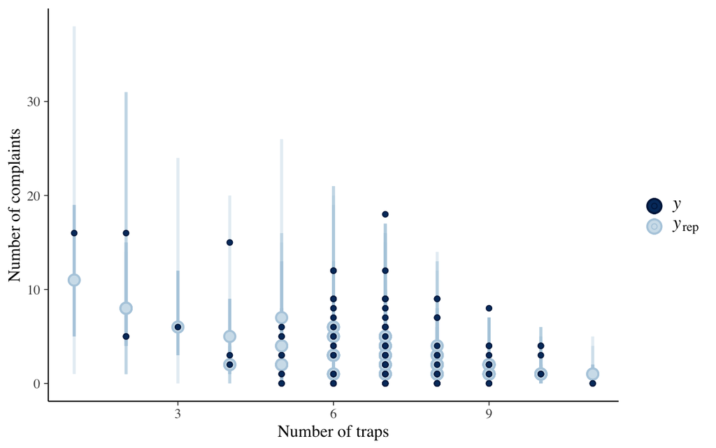

```r
## prediction by number of traps
ppc_intervals(
  y = stan_dat_simple$complaints,
  yrep = y_rep,
  x = stan_dat_simple$traps
) +
  labs(x = "Number of traps", y = "Number of complaints")
```

Looks OK but… Data are clustered by building. A posterior predictive check can help us understanding if it would be a good idea to add the building information into the model.

```r
ppc_stat_grouped(
  y = stan_dat_simple$complaints,
  yrep = y_rep,
  group = pest_data$building_id,
  stat = 'mean',
  binwidth = 0.2
)
```

[figure not shown]

We’re getting plausible predictions for most building means but some are estimated better than others and some have larger uncertainties than we might expect. If we explicitly model the variation across buildings we may be able to get much better estimates.

… to be continued